# Avaliação 2 - Valor: 33 pontos

Introdução à Ciência de Dados - 2025  
Bacharelado em Administração

Autores

Gabrielle Ferreira

Rafaella Candelari

Gabriela Silva

Data de Publicação

18 de junho de 2025

## Questão 1

**a)** Probabilidade anual de sinistro|1% Indenização média por sinistro|R$ 150.000 Margem-alvo sobre o prêmio puro|25%

```r
prob_sinistro <- 0.01
indenizacao_sinistro <- 150000

# Cálculo do prêmio
premio_justo <- prob_sinistro * indenizacao_sinistro
premio_justo
```

```
[1] 1500
```

**b)**

```r
margem_alvo <- 0.25

# Cálculo do prêmio comercial
premio_comercial <- premio_justo * (1 + margem_alvo)
premio_comercial
```

```
[1] 1875
```

**c)**

```r
## fixa a semente para reprodutibilidade
set.seed(2025)

## simula o custo para 10 residências seguradas
custos_10 <- sample(
  c(0, 150000),        # preencha com os dois valores de custos possíveis: sem sinistro e com sinistro
  size = 10,          # número total de residências a serem simuladas
  replace = TRUE,       # indique se a amostragem será com reposição
  prob = c(1 - 0.01, 0.01)  # probabilidades de cada um dos dois resultados (sinistro e não sinistro)
  )

## estimativa do custo médio por apólice com 10 residências seguradas
mean(custos_10)
```

```
[1] 0
```

Simulação dos custos médios com 100 residências seguradas:

```r
set.seed(2025) # Mantém

custos_100 <- sample(
  c(0, 150000),
  size = 100, # 100 residências
  replace = TRUE,
  prob = c(1 - 0.01, 0.01)
)

mean(custos_100) # Custo médio para 100 residências
```

```
[1] 4500
```

Simulação dos custos médios com 1000 residências seguradas:

```r
set.seed(2025) # Mantém

custos_1000 <- sample(
  c(0, 150000),
  size = 1000, # 1000 residências
  replace = TRUE,
  prob = c(1 - 0.01, 0.01)
)

mean(custos_1000) # Custo médio para 1000 residências
```

```
[1] 1500
```

**d)**

Pela Lei dos Grandes Números,pois em muitas apólices, o custo médio se aproxima do valor esperado, tornando o negócio previsível e lucrativo a longo prazo.

**e)** Diminui pois o segurado arca com R$ 50.000 comisso ela pode ela pode cobrar um premio menor do cliente, ou manter o prêmio e aumentar sua margem de lucro.

## Questão 2

**a)**

```r
media_entrega <- 6.5       # Média de 6.5 dias
desvio_padrao_entrega <- 1.8 # Desvio padrão de 1.8 dias

prob_sup_8_dias <- 1 - pnorm(q = 8, mean = media_entrega, sd = desvio_padrao_entrega)

#RESULTADO
prob_sup_8_dias
```

```
[1] 0.2023284
```

```r
prob_sup_8_dias_pct <- prob_sup_8_dias * 100
prob_sup_8_dias_pct
```

```
[1] 20.23284
```

**b)**

```r
prazo_maximo_90_pct <- qnorm(p = 0.90, mean = media_entrega, sd = desvio_padrao_entrega)

#RESULTADO
prazo_maximo_90_pct
```

```
[1] 8.806793
```

**c)**

```r
# Probabilidade de do prazo de 7 dias
prob_cumprir_7_dias <- pnorm(q = 7, mean = media_entrega, sd = desvio_padrao_entrega)

#RESULTADO
prob_cumprir_7_dias
```

```
[1] 0.6094085
```

```r
prob_cumprir_7_dias_pct <- prob_cumprir_7_dias * 100
prob_cumprir_7_dias_pct
```

```
[1] 60.94085
```

## Questão 3

**a)**

```r
# Parâmetros fornecidos
media_vendas <- 18500
desvio_padrao_vendas <- 2300
vendas_loja <- 21800

score_z <- (vendas_loja - media_vendas) / desvio_padrao_vendas
score_z
```

```
[1] 1.434783
```

**b)**

```r
prob_acumulada <- pnorm(q = vendas_loja, mean = media_vendas, sd = desvio_padrao_vendas)
prob_acumulada_pct <- prob_acumulada * 100
prob_acumulada_pct
```

```
[1] 92.43255
```

RESPOSTA: Significa que a loja teve um desempenho superior das outras lojas e só 7%, das lojas teve um desempenho igual ou melhor que o dela naquele dia

**c)**

```r
percentil_90_vendas <- qnorm(p = 0.90, mean = media_vendas, sd = desvio_padrao_vendas)
percentil_90_vendas
```

```
[1] 21447.57
```

```r
# Compara as vendas da loja com o limite do percentil 90
desempenho_excepcional <- vendas_loja > percentil_90_vendas
```

RESPOSTA: Muito bom pois superou 10%

## Questão 4

**a)**

```r
# Parâmetros
retorno_medio_portfolio <- 0.011
desvio_padrao_portfolio <- 0.042
valor_investimento_atual <- 400000
nivel_confianca_var <- 0.99

#Calculo do quantil do retorno correspondente ao nível de confiança
quantil_retorno_var <- qnorm(p = (1 - nivel_confianca_var),
                             mean = retorno_medio_portfolio,
                             sd = desvio_padrao_portfolio)

# Porcentagem
var_percentual_q4 <- abs(quantil_retorno_var) * 100
```

Cálculo do VaR 99% percentual:

```r
var_monetario_q4 <- (var_percentual_q4 / 100) * valor_investimento_atual
#RESULTADO
cat("VaR Percentual (99% de confiança): ", round(var_percentual_q4, 2), "%\n")
```

```
VaR Percentual (99% de confiança):  8.67 %
```

Cálculo do VaR 99% monetário (valor absoluto da perda):

```r
cat("VaR Monetário (99% de confiança): R$ ", round(var_monetario_q4, 2), "\n")
```

```
VaR Monetário (99% de confiança): R$  34682.64
```

**b)** Em 99% dos meses, a perda esperada para esta aplicação não deve exceder R$ 34.683,00

**c)**

A assimetria e a curtose elevada (caudas gordas). A assimetria negativa implica que grandes perdas são mais frequentes do que o previsto por uma curva normal simétrica. Já as caudas gordas indicam que eventos extremos (grandes oscilações) ocorrem com mais frequência do que a distribuição normal.

## Questão 5

- A
- B
- C
- D
- E

Por que as demais estão erradas?

- **A** - Apesar de ter um numero absoluto pequeno a taxa de Santa Luzia é a segunda maior
- **B** - As políticas públicas são ações que os governos precisam atender o direito das mulheres, garantindo a segurança delas e não colocando-as como responsaveis
- **C** - Está errada pois esses paises tem os maiores numeros absolutos e não as maiores taxas como Honduras, Santa Lúcia e Trindade e Tobago.
- **E** - Não pois apesar do numero total ser elevado ainda existem taxas maiores

## Questão 6

**a)**

```r
dados_precos <- c("PETR4.SA", "WEGE3.SA") %>%
  tidyquant::tq_get(from = "2024-01-01") %>%
  dplyr::select(symbol, date, close) %>%
  tidyr::pivot_wider(names_from = symbol, values_from = close) %>%
  dplyr::rename(petrobras = "PETR4.SA", weg = "WEGE3.SA")
#RESULTADO
head(dados_precos)
```

```
# A tibble: 6 × 3
  date       petrobras   weg
  <date>         <dbl> <dbl>
1 2024-01-02      37.8  36.6
2 2024-01-03      39.0  36.8
3 2024-01-04      38.6  36.4
4 2024-01-05      38.7  36.0
5 2024-01-08      38.4  36.1
6 2024-01-09      38.1  35.2
```

**b.1)**

```r
# cálculo dos retornos logarítmicos
dados_ret <- dados_precos %>%
# a função `mutate()` adiciona as colunas de retornos
mutate(ret_petrobras = log(petrobras / lag(petrobras)),
     ret_weg       = log(weg       / lag(weg))) %>%
# drop_na remove a linha com retorno faltante (NA)
drop_na()

# exibição das primeiras linhas
head(dados_ret)
```

```
# A tibble: 6 × 5
  date       petrobras   weg ret_petrobras  ret_weg
  <date>         <dbl> <dbl>         <dbl>    <dbl>
1 2024-01-03      39.0  36.8       0.0308   0.00763
2 2024-01-04      38.6  36.4      -0.00851 -0.0134
3 2024-01-05      38.7  36.0       0.00233 -0.0108
4 2024-01-08      38.4  36.1      -0.00752  0.00250
5 2024-01-09      38.1  35.2      -0.00862 -0.0250
6 2024-01-10      37.8  35.3      -0.00923  0.00426
```

**b.2)**

```r
correlacao_retornos_log <- cor(dados_ret$ret_petrobras,
                               dados_ret$ret_weg,
                               method = "pearson",
                               use = "complete.obs") # Ignora NAs se houver
#RESULTADO
round(correlacao_retornos_log, digits = 4)
```

```
[1] 0.1375
```

**b.3)**

```r
interpret_r(correlacao_retornos_log, rules = "cohen1988")
```

```
[1] "small"
(Rules: cohen1988)
```

```r
interpretacao_cohen_retornos <- as.character(interpret_r(correlacao_retornos_log, rules = "cohen1988"))
```

**c)**

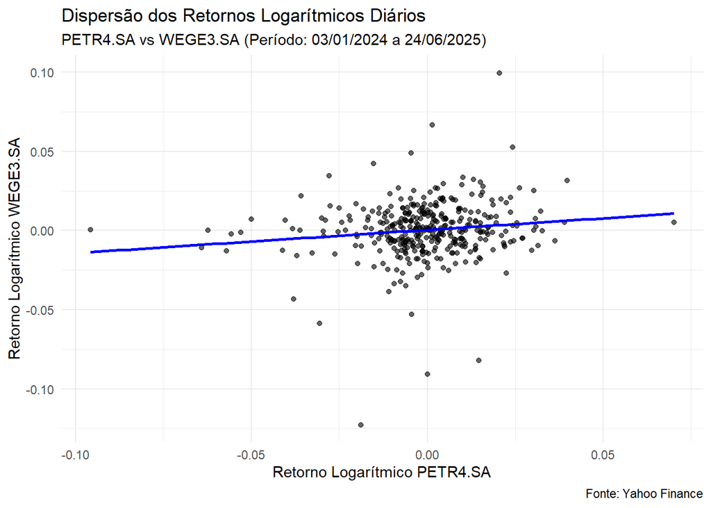

```r
# Datas mínima e máxima para o subtítulo
data_min <- min(dados_ret$date)
data_max <- max(dados_ret$date)

grafico_dispersao_retornos <- ggplot(dados_ret, aes(x = ret_petrobras, y = ret_weg)) +
  geom_point(alpha = 0.6) + # Pontos com transparência
  geom_smooth(method = "lm", se = FALSE, color = "blue") + # Reta de regressão linear em azul
  labs(title = "Dispersão dos Retornos Logarítmicos Diários",
       subtitle = paste0("PETR4.SA vs WEGE3.SA (Período: ", format(data_min, "%d/%m/%Y"), " a ", format(data_max, "%d/%m/%Y"), ")"),
       x = "Retorno Logarítmico PETR4.SA",
       y = "Retorno Logarítmico WEGE3.SA",
       caption = "Fonte: Yahoo Finance") +
  theme_minimal()
#RESULTADO
grafico_dispersao_retornos
```